```r
# packages used:
install.packages('tidyverse')
install.packages('corrr')
devtools::install_github("lbelzile/hecedsm")
```

```r
library('tidyverse')
library('naniar')
library('corrr')
```

# Case Study 1: Smartwatches are More Distracting Than Mobile Phones While Driving.

Alan Lee  
Feb 2, 2026

#### NOTE:

Hello, I tried to separate the document into assignment questions in square brackets for easier marking (eg. [1],[2],[3]). Figure names were not coded as I thought it looked better in Markdown cell above the graph.

## Task 1 Choosing the Dataset

```r
# loading the data# data used for workbook
#[1]
library(hecedsm)
data <-BRLS21_EDA
```

## Goals and Hypothesis

[2]

This study compared whether smartwatches were more distracting or impacted driving more negatively than smartphones, voice systems, or texting while driving. This is important as smart watches are expected to be the most popular form of wearable technology in the US but can be a potential source of distraction when driving. However most laws in the US however do not specifically prohibit smartwatches like they do other technology such as smartphones which leaves its legality open to interpretation. This study therefore aims to expand on previous smartwatch research and provide more data on how smartphones compare to other devices in terms of one’s attentional state and driving behaviour. This could improve designs by law/policy makers and the smartwatch industry to accurately handle the risks of smartwatches.

Their hypotheses were that for attention and driving behaviour, people would be least focused when responding manually by text then orally by smartwatches, smartphones, and finally least impacted by speakerphone. Mental workload similarly would be highest when responding by text, then smartwatch, smartphones, and finally lowest with speakers. Results supported the distraction hypothesis but did not support the driving performance hypothesis (except texting which degraded driving) or the mental workload hypothesis.

## Task 2 Exploring the Data

#### Table 1: Overview of Data and Variables

```r
# data overview
# [3 & 4]
glimpse(data)
```

```
Rows: 10,942
Columns: 6
$ id        <fct> 1, 1, 1, 1, 1, 1, 1, 1, 1, 1, 1, 1, 1, 1, 1, 1, 1, 1, 1, 1, …
$ reltime   <int> 0, 1, 2, 3, 4, 5, 6, 7, 8, 9, 10, 11, 12, 13, 14, 15, 16, 17…
$ task      <fct> baseline, baseline, baseline, baseline, baseline, baseline, …
$ occurence <int> 1, 1, 1, 1, 1, 1, 1, 1, 1, 1, 1, 1, 1, 1, 1, 1, 1, 1, 1, 1, …
$ eda       <dbl> 20.60959, 21.41062, 22.26244, 24.22100, 24.23851, 23.63703, …
$ hr        <dbl> 88.49560, 88.31564, 78.13892, 65.82009, 65.13290, 66.83456, …
```

#### Table 2: Missing Values in the Data

```r
# [6] missing variables
miss_var_summary(data)
```

A tibble: 6 × 3

| variable <chr> | n_miss <int> | pct_miss <num> |
| --- | --- | --- |
| hr | 538 | 4.92 |
| eda | 214 | 1.96 |
| id | 0 | 0 |
| reltime | 0 | 0 |
| task | 0 | 0 |
| occurence | 0 | 0 |

## Data Description

[3-6]

The dataset has 6 columns (6 variables) and 10,942 rows (observations).

There are 4 numerical variables (reltime, occurence, eda, hr) and 2 categorical variables (id and task). ID appears as a numeric value but it represents the participant ID (1-31) and should be treated as categorically.

At this time it does not look like the variables need to be transformed. ID and task are a factor already so it will be treated as a category. reltime and occurence are integers so they will measure discrete events. eda and hr doubles so they are continuous numbers and ready for more precise calculations.

The dataset only has missing values in hr and eda. It has 538 missing values in hr or about 4.92% missing and 214 missing values in eda or about 1.96%. In neither cases are there a large proportion of missing values (>20%).

```r
# Visualize Category Imbalance
#[7]
cat_distr_plot <- data |>
select(where(is.factor)) |>
    pivot_longer(everything(),
               names_to = "variable",
               values_to = "value") |>
    count(variable, value) |>
    ggplot(aes(x = n, y = value)) +
    geom_col() +
    facet_wrap(~variable, scales = "free", ncol =1) +
    theme(axis.text.x = element_text(angle = 45, hjust = 1))+
    theme(figure.size = c(15, 10))
```

[output not shown]

cat_distr_plot

## Task 3: Exploring the Data

```r
# plot two numerical variables
# [8]
hr_time_plot <- data|>
ggplot(aes(x=reltime, y =hr))+
geom_jitter(width = 0.1, alpha = 0.2, color = "cornflowerblue")+
labs(x = "Relative Time (mins)", y = "Heart Rate (bpm)")+
theme_minimal()
```

#### Figure 2: Heart Rate Over Time (relative to experiment start)

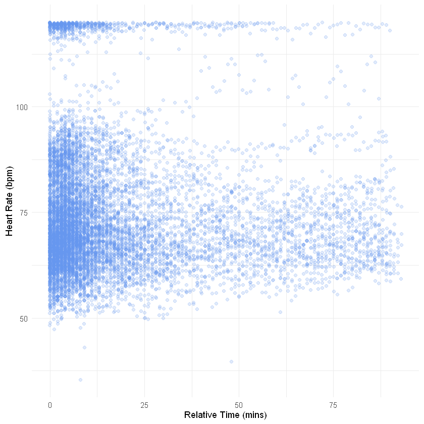

```r
hr_time_plot
```

[8] Figure 2 explores the relationship between the participant heart rate and relative time since the experiment starts. Since heart rate is a continuous variable and relative time is a numeric but distinct variable a jitterplot with low alpha for each point was used. This was so many datapoints plotted on the same minute integer could still be seen and not obscured by other heart rate values also at that same integer value.

From the plot above there does not seem to be a meaningful relationship between time and ones heart rate. If the data were grouped perhaps by participant or task (and different groups colored or faceted) we might find more meaning. For example there looks likes there could be multiple trends of heart rates one on the higher end above 100 and one centered around 60. A pearson correlation was not run as there wasn't an apparent single trend in the chart above.

```r
# Histogram of Electrodermal Activity
# [9]

eda_hist_plot<- data |> ggplot(aes(x=eda))+
geom_histogram(fill ="cornflower blue")+
labs(x = 'Electrodermal Activity', y = 'Count')+
theme_minimal()

# bins were not adjusted because the resulting graph looks pretty good with default settings
```

#### Figure 3: Distribution of Electrodermal Activity

```
Warning message:
"Removed 214 rows containing non-finite outside the scale range (`stat_bin()`)."
```

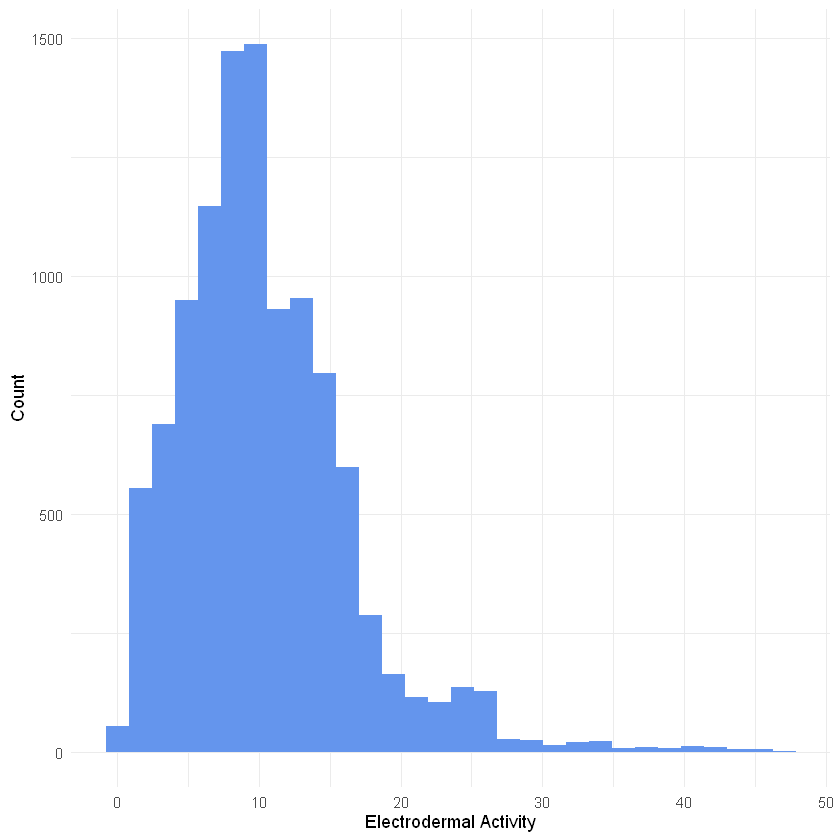

```r
eda_hist_plot
```

[9] From Figure 3, we can see that the electrodermal activity data we have has a fairly unimodal distribution that is skewed to the right. It appears to have a peak around 9 or 10 and higher valued outliers which cause its skew. Most data appears between a value of 0 to 20 but its tail extends almost until 50.

```r
# Violin plot of heart rate and task
# [10]
hr_task_plot <- data|>
ggplot(aes(x=task, y =hr, fill = task))+
geom_violin()+
labs(x = "Task", y = "Heart Rate (bpm)")+
theme_minimal()+
theme(legend.position = "none")+
scale_x_discrete(labels = c("baseline" = "Baseline",
                                "cell" = "Smartphone",
                                "voicecall" = "Voice Call",
                           "watch" = "Smart Watch"))
```

#### Figure 4: Violin Plot of Heart Rate Across Treatment Conditions

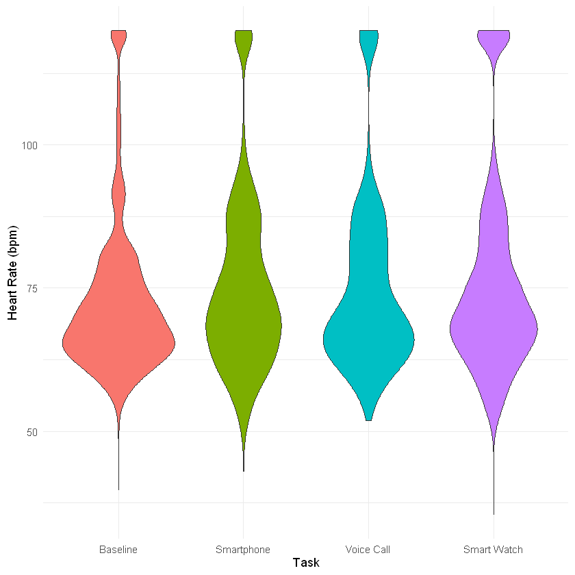

```r
hr_task_plot
```

[10] From Figure 4, we can see that the heart rate remains similar across all treatment conditions and the baseline showing only slightly lower center. The heart rate seems centered around a value of 60-70 bpm except the baseline which is centered a little lower and wider. This would make sense as no condition was applied to the drivers yet and they were driving without any notifications to affect them. Further the range between all conditions seems to be similar with a similar spread except the baseline which is slightly wider violin for the baseline condition. However, all violins have long tails that widen slightly at the extreme values suggesting there may have been spikes for all conditions unless some participants had high heart rates measured across all the tasks they did.

```r
# Bar chart of Task
# [11]

task_bar_plot<- data |>  ggplot(aes(x = task, fill = task)) +
geom_bar() +
labs(x = "Task", y = "Count") +
theme_minimal()+
theme(legend.position = "none") +
scale_x_discrete(labels = c("baseline" = "Baseline",
                                "cell" = "Smartphone",
                                "voicecall" = "Voice Call",
                           "watch" = "Smart Watch"))
```

#### Figure 5: Distribution of Tasks (Treatment Conditions)

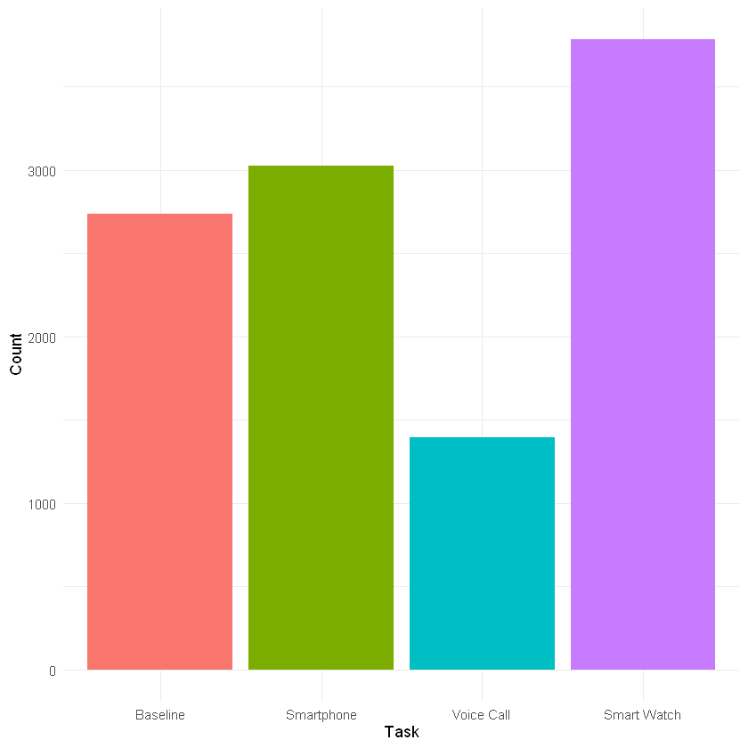

```r
task_bar_plot
```

## Task 4 Summary Statistics

```r
# Median of Electrodermal Activity
# [12]
median(data$eda, na.rm=TRUE)
mean(data$eda, na.rm=TRUE)
```

9.366185

10.3949337453393

[12] Electrodermal Activity's central tendancy is best measured with a median due to most of its values falling between 0-20 but large outliers reaching as high as the 40-50 range. The median would therefore be a robust measure of central tendancy.

The median electrodermal activity measure was 9.37.

(For reference, the mean was calculated too and was 10.39 which is higher showing the influence of the outliers.)

```r
#[13]
# mode task
data|> group_by(task)|>
summarize(count=n())|>
arrange(desc(count))

# proportions of tasks
prop.table(table(data$task))
```

A tibble: 4 × 2

| task <fct> | count <int> |
| --- | --- |
| watch | 3786 |
| cell | 3028 |
| baseline | 2736 |
| voicecall | 1392 |

```
 baseline      cell voicecall     watch
0.2500457 0.2767319 0.1272162 0.3460062
```

[13] For the summary statistic for a categorical variable, the one we learned in class is the mode. Smartwatches were the most commonly observed task in our data with 3786 observations. Another useful statistic might be proportions with smartwatch at 35% of the observations. The other categories are shown in the results above too for example smartphones (cell) at 27.6%, voice calls at 12.7% and the baseline at 25%. This is informative as it informs us on the distribution of the categorical variable and if anything is overrepresented or underrepresented.

```r
# pearson correlation of eda and hc
#[14]
correlate(data$eda,data$hr)
```

```
Correlation computed with
• Method: 'pearson'
• Missing treated using: 'pairwise.complete.obs'
```

A cor_df: 1 × 2

| term <chr> | x <dbl> |
| --- | --- |
| x | 0.1435454 |

[14] One measure of association between the electrodermal activity (eda) and heart rate is the pearson correlation of 0.14. This suggests there is a weak positive relationship between the two. As heart rate increases the eda also tends to slighlty increase and vice versa. The cofficient also means that these variables have a squared correlation of 0.0196 which means they explain about 2% of the variation noticed in eachother.

# Task 5 Develop a Question

[15] If I were the author of this paper and needed to use this dataset, another research question we could pursue is: Is receiving notifications on a smartwatch more stress inducing than on smartphone or voicebased systems? This would be under the assumption that electrodermal activity is a useful way to operationalize and measure stress.

[16] In the above scenario, it would not be necessary to split the data into test and training sets because we are performing inference testing on experimental results. Splitting my data into training and test data is always useful for machine learning and for predictions where we do not want the model to have peeked at the data we would use to evaluate it's accuracy with later. However, in the research question above, we are analyzing the results of our experiment to see if there is a difference between the treatment condition involving smartwatches and the other conditions involving smartphones and speakers in a within-subject experiment.

```r
# creating a new feature: stress index
#[17]
data <- data|>
mutate(
    eda_zscore = scale(eda),
    hr_zscore = scale(hr),
    stress_index = ((eda_zscore + hr_zscore) / 2)
  )
```

#### Table 3: Dataset With Stress Index Added (First 6 rows)

```r
head(data)
```

A tibble: 6 × 9

| id <fct> | reltime <int> | task <fct> | occurence <int> | eda <dbl> | hr <dbl> | eda_zscore <dbl[,1]> | hr_zscore <dbl[,1]> | stress_index <dbl[,1]> |
| --- | --- | --- | --- | --- | --- | --- | --- | --- |
| 1 | 0 | baseline | 1 | 20.60959 | 88.49560 | 1.700278 | 0.9089505 | 1.3046143 |
| 1 | 1 | baseline | 1 | 21.41062 | 88.31564 | 1.833613 | 0.8971469 | 1.3653801 |
| 1 | 2 | baseline | 1 | 22.26244 | 78.13892 | 1.975403 | 0.2296489 | 1.1025258 |
| 1 | 3 | baseline | 1 | 24.22100 | 65.82009 | 2.301414 | -0.5783516 | 0.8615314 |
| 1 | 4 | baseline | 1 | 24.23851 | 65.13290 | 2.304329 | -0.6234249 | 0.8404521 |
| 1 | 5 | baseline | 1 | 23.63703 | 66.83456 | 2.204210 | -0.5118118 | 0.8461990 |

[17] The new feature I created is the stress index. It is based on the assumption that both heart rate and electrodermal activity (eda) will contribute meaningfully to the measurement of one's stress. However since the heart rate and eda are measured in different units and scales, the scale() function was used to get the z-score of that observation so the two variables could be combined into one index. I think this will meaningfully allow us to use all the relevant data from this experiment. I think it is reasonable given the data available to assume that eda and hr are useful and different ways to understand someone's level of stress.

## Task 6: Design Description

[18] The authors are answering causal questions but by using statistical inference techniques so the best description would be causal inference. This case differs from our experiences in DSCI 100 where we worked with observational studies because here the researchers placed all participants in a within-subject experiment. Each subject was intended to experience each treatment condition in random order which also helps rule out confounders like becoming tired or learning effects. In this case it is both causal because the differences observed between the treatment conditions can be attributed to manipulating the condition. It also involves inference because of how it answers these questions such as using inference testing.

[19] The population this study describes would be young adult to middle age drivers found in the Montreal area. Considering the study cited the legal grey area of smartwatches while driving in the US but is funded by public research money in Canada, the population of interest were probably drivers in North America.

The sample appears to be a non-random volunteer sample as participants chose from a list of ongoing experiments from the research panel's website (p.3). Given that the participants were paid $30 and the recruited through the institution's recruitment panel at Tech3Lab in the University of Montreal, it might be safe to assume they are young adult to middle-aged drivers from the Montreal area. These volunteers were screened to exclude people with skin allergies, pacemakers, epilepsy, and other neurological, psychiatric, or health problems. The sample had 31 participants, with 16 male and 15 female with 6 participants having an accident within the last 3 years. The participant's ages were between 20-47 with an average of 25.61 years.

Due to the non random and volunteer nature of this sample, the limited age, the likely specific geography of the participants, and the exclusions made, it might not be possible to generalize the results of this study to the intended population.

[20] This was an experiment and not a observational study. The researchers designed several treatment conditions which the participants were assigned to in random order. As a within-subject experiment each participant was intended to experience all conditions so that they could reduce confounders and hold constant features of that person across conditions. This is different from an observational study where researchers could only observe how participants would behave naturally and self select into their preferred behaviours (which devices they would check and how they would respond).

## Task 7: Design Analysis

[21] The researchers were able to control for a number of potential confounders due to their experimental design. The within-subject design where participants were intended to be exposed to each treatment condition meant variables related to them as individuals were held constant across the conditions such as their age, gender, experience driving, skill, and familiarity with technology among others. It also prevented biases that would arise from self selection. Since the order of the conditions were randomly assigned to each participant, this helped control for fatigue or experience with the driving simulator over time from confounding their results. Participants with health conditions that could affect the measurement of their results were screened out and a "vanilla" baseline was taken to help further control for individual physiological factors affecting the measurements (pp.3-4).

The notifications and their length were also identical to each participant to control for any confounders where some people might receive more distracting messages and the order the messages were given were also randomized to ensure there were no order effects as well. The devices used and the driving environments were identical to by giving participants the same devices and driving simulator so these differences in device or driving course could not confound these results.

However, some confounders were not addressed. For example the authors note that they chose not to add a control condition with no-notifications/distractions. They noted that the sampling method they used left older drivers unrepresented. They also noted their limited number of driving performance measure and devices could also be a source of confounding. I would like to add the volunteer sampling around a university lab not only means you will get a larger number of young volunteers but also that the geography, culture, and socioeconomic status of these people could be a confounder. Urban youth in the current generation might not have driving experience compared to someone in rural community that must drive as part of daily life.

[23] There were several sources of sampling bias that could have affected the studies conclusions. First it was a volunteer sample where participants would self register into ongoing studies of interest to them from the lab’s website (p.3). Volunteers wanted to participate in the driving simulator and were willing to come to the university lab (Tech3Lab) for $30 and at the cost of over at least an hour of their time. This predisposes the participants to be younger (as reflected by the young age of most participants) and possibly associated with the university culture. It might also bias the sample toward those who are more comfortable using technology or have an interest in it which means they may interact with the technology differently than other parts of the population. The geography of coming to a university lab might also bias the sample against those who are older, work one or more full time jobs, or have families as well as those living in rural areas or farther away who could not easily come to the lab during working hours. The geography could also tie into cultural differences that would affect how people interact with wearable technology or norms about their use when driving.

Each of these groups could relate to technology differently than those able to volunteer or have different levels of experience with wearable technology and therefore need to give the different devices different levels of attention. The within-subject design will hold constant factors across the treatment conditions but missing factors (like old age) might interact with the technology in unexpected ways.

## Task 8 Personal Changes to Sampling or Design

[24] If I were to design this study myself and I had an unlimited budget, I would like to use a different sampling method to make the results more generalizable. I would like to use a stratified sampling method or even stratified volunteer samples and larger n to better capture the different parts of the population the authors missed. This could include, geography, age, or socioeconomic variables to name some. For example, the authors recognize that older drivers are not represented and this is important as older people interact with technology differently whereas 24/31 participants in the sample were in their 20’s (p.8). If I had the same budget, I might do the similar study but I think it would be worth trying to recruit more older drivers and to spend some battery time on running a control condition as the authors suggested and see how this compares to undistracted driving. The within-subject experimental design would still be useful for holding variables constant across treatment conditions and to reduce confounders. One immediate reason not to pursue this however is cost. It would be difficult to either pay or fund some alternate way to compel randomly selected people to participate in this study. Even then, there would be a good argument this topic is not worth those resources which could better fund other studies that are more impactful.

Cost and convenience is also the likely reason the authors chose their sampling and design methods. Using volunteers that would come to their university lab for a couple hours for $30 likely made this study possible but likely also contributed to why 24/31 participants were 20-26 years old. They mentioned they only had 45 minutes of battery life and so omitted a control to be able to record more data from the treatment condition, so it seems they had to make the most of their resources. Alternatives like random sampling or stratified sampling would be too costly as you would need to bring participants into your lab.

Also on the topic of costs, this study is publicly funded by the SSHRC which makes it more impartial. Another change is this exploratory research could be funded by the manufacturers in part or wholly. Maybe some of that money Tim Cook saved from not giving consumers charging bricks and earphones anymore could have gone to research on how their products affects drivers. It would benefit them to be taking the initiative on this conversation too.

## References

• Brodeur, M., Ruer, P., Léger, P., & Sénécal, S. (2021). Smartwatches are More Distracting Than Mobile Phones While Driving: Results From an Experimental Study. Accident Analysis and Prevention, 149, 105846. https://doi.org/10.1016/j.aap.2020.105846